GeoStat Lab · M10 · Previsione e progetto statistico

M10_N10 · Futura

# Percorso obbligatorio e approfondimento

5 blocchi R eseguiti1 grafico0 errori · 0 avvisiOffline · MathML

Codice, output e figure dello stesso svolgimento. Ogni notebook riparte dai dati locali ed è autonomo rispetto agli altri.

# La domanda

Quale domanda affronta il progetto base e quale il sistema VAR?

## Obiettivi

- Identificare unità osservativa e bersaglio.
- Controllare i fossili prima della regressione.
- Separare il progetto morfometrico dall’approfondimento temporale.

**Prima di iniziare.** Sono richiesti vettori, tabelle e funzioni R di base. I blocchi vanno eseguiti in ordine. Il notebook è autonomo rispetto agli altri.

**Dati e unità.** 160 fossili sintetici del corso. Diametri e spessore sono espressi in micrometri. Il diametro interno deriva dal totale meno due volte lo spessore, entro l’arrotondamento del CSV. Il test contiene ogni quinta riga: 32 individui, separati dai 128 usati per stimare. È un protocollo didattico su dati già noti, non una validazione prospettica. Processi sintetici di 300 passi, senza unità fisica. Le colonne x_VAR e y_VAR costituiscono un sistema bivariato. Usiamo i passi 1–250 per stimare e, quando richiesto, 251–260 per una previsione a origine fissa. La prima riga è una condizione iniziale finita: l’esempio non equivale a una nuova serie osservativa.

## Preparazione

Aprire il progetto autonomo di Futura o quello generale del corso. I calcoli usano R base e stats. Gli output del notebook vanno in `Risultati/M10_N10/`; i CSV originali restano invariati.

Codice R · preparazione

```r
# Trova la cartella M10 dal progetto autonomo o dal progetto generale.
.gs_cerca <- normalizePath(getwd(),winslash="/",mustWork=TRUE)
repeat {
  .gs_candidati <- c(.gs_cerca,
    file.path(.gs_cerca,"M10_Futura"),
    file.path(.gs_cerca,"03_Notebook_svolti","M10_Futura"),
    file.path(.gs_cerca,"M10","03_Notebook_svolti","M10_Futura"))
  .gs_ok <- file.exists(file.path(.gs_candidati,"M10_N01.Rmd")) &
    file.exists(file.path(.gs_candidati,"R","funzioni_notebook.R"))
  if(any(.gs_ok)) { .gs_modulo <- .gs_candidati[which(.gs_ok)[1L]]; break }
  .gs_padre <- dirname(.gs_cerca)
  if(.gs_padre==.gs_cerca) stop("Aprire il progetto M10_Futura o quello generale dei notebook.")
  .gs_cerca <- .gs_padre
}
source(file.path(.gs_modulo,"R","funzioni_notebook.R"),local=TRUE)
.gs_funzioni <- .gs_prepara_notebook(.gs_modulo,"M10_N10")
carica_dati <- .gs_funzioni$carica_dati
percorso_risultati <- .gs_funzioni$percorso_risultati
options(width=88,digits=6)
if(requireNamespace("knitr",quietly=TRUE)) {
  knitr::opts_chunk$set(echo=TRUE,error=FALSE,warning=TRUE,message=TRUE,
    fig.width=8,fig.height=5,dpi=150,fig.align="center")
}
set.seed(10010)
```

## 1. Una domanda per ciascun dataset

Il progetto base riguarda individui, il VAR riguarda una successione bivariata. Una tabella di progetto mantiene esplicita questa differenza.

Codice R · passo_01

```r
progetti <- data.frame(percorso=c("Base morfometrico","Approfondimento VAR"),
  unita=c("Fossile sintetico","Passo temporale sintetico"),
  bersaglio=c("Diametro interno","X e Y future"),
  verifica=c("32 individui esclusi","Passi 251-260"))
progetti
```

Output eseguito

```
             percorso                     unita        bersaglio             verifica
1   Base morfometrico         Fossile sintetico Diametro interno 32 individui esclusi
2 Approfondimento VAR Passo temporale sintetico     X e Y future        Passi 251-260
```

**Lettura del risultato.** I due percorsi condividono audit e validazione, ma richiedono split e interpretazioni diversi.

## 2. L’audit precede il modello

Controlliamo identificativi e vincoli fisici, senza cancellare osservazioni automaticamente.

Codice R · passo_02

```r
f <- carica_dati("fossili_simulati.csv")
audit <- data.frame(controllo=c("ID unici","Diametri completi","Totale positivo","Interno entro totale"),
  esito=c(!anyDuplicated(f$id),!anyNA(f[c("diametro_tot_um","diametro_int_um")]),
    all(f$diametro_tot_um>0),all(f$diametro_int_um>0 & f$diametro_int_um<=f$diametro_tot_um)))
audit
stopifnot(all(audit$esito))
```

Output eseguito

```
             controllo esito
1             ID unici  TRUE
2    Diametri completi  TRUE
3      Totale positivo  TRUE
4 Interno entro totale  TRUE
```

**Lettura del risultato.** Un esito positivo significa coerenza con i controlli adottati, non assenza di ogni possibile problema.

## 3. Il legame geometrico limita la spiegazione

Il rapporto fra diametri contiene già il bersaglio. Non è disponibile prima di misurare il diametro interno.

Codice R · passo_03

```r
scarto <- f$diametro_int_um-(f$diametro_tot_um-2*f$spessore_um)
data.frame(n=nrow(f),massimo_scarto_geometrico=max(abs(scarto)))
stile_grafico()
plot(f$diametro_tot_um,f$diametro_int_um,pch=19,col=palette_geo[1],
  xlab="Diametro totale (micrometri)",ylab="Diametro interno (micrometri)",
  main="Misure sintetiche geometricamente legate")
abline(0,1,lty=2)
```

Output eseguito

```
    n massimo_scarto_geometrico
1 160                     1e-08
```

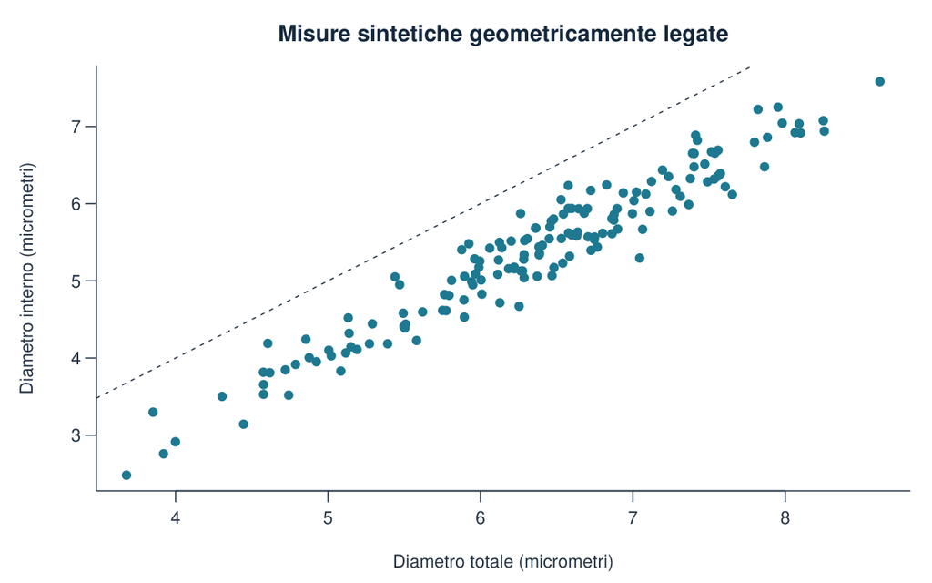

Figura 1 · Output del blocco `passo_03`. PDF vettoriale.

**Lettura del risultato.** Una forte associazione è in parte incorporata nella costruzione geometrica. Non basta per attribuire un meccanismo causale indipendente.

## Variante svolta

**Il protocollo è una tabella.** Scrivere prima del modello gli elementi minimi della consegna.

Codice R · variante

```r
piano <- data.frame(voce=c("Domanda","Input disponibile","Bersaglio","Split","Riferimento"),
  scelta=c("Prevedere il diametro interno","Diametro totale","Diametro interno in micrometri",
  "Ogni quinta riga nel test","Media del solo train"))
write.csv(piano,percorso_risultati("piano_progetto.csv"),row.names=FALSE)
piano
```

Output eseguito

```
               voce                         scelta
1           Domanda  Prevedere il diametro interno
2 Input disponibile                Diametro totale
3         Bersaglio Diametro interno in micrometri
4             Split      Ogni quinta riga nel test
5       Riferimento           Media del solo train
```

Il piano rende riconoscibili cambiamenti effettuati dopo aver visto i risultati.

## Errore da riconoscere

Mescolare individui e tempi nella stessa strategia di split, oppure introdurre il rapporto interno/totale come predittore ignoto all’atto della previsione.

## Risposta alla domanda

Il percorso base verifica una regressione morfometrica su individui sintetici. Il VAR approfondisce la previsione di un sistema temporale. Domande, unità e limiti restano distinti.

## Riferimento nel corso

Questo svolgimento sviluppa il laboratorio `M10_N10` di [GeoStat Lab M10](https://marzione00.github.io/Lab_Geo/#indice). Il [codice originale del laboratorio](https://github.com/marzione00/Lab_Geo/blob/649f7cc577b96bd1044d81e78a2f530813e4f96b/materiali/laboratori/M10/M10_N10.R) è conservato anche in `R/Originali_corso`. Gli ampliamenti e le varianti sono identificati nella mappa allegata.

Documentazione dei metodi: [R stats, arima](https://stat.ethz.ch/R-manual/R-devel/library/stats/html/arima.html), [predict.Arima](https://stat.ethz.ch/R-manual/R-devel/library/stats/html/predict.arima.html), [Box.test](https://stat.ethz.ch/R-manual/R-devel/library/stats/html/box.test.html) e [p.adjust](https://stat.ethz.ch/R-manual/R-devel/library/stats/html/p.adjust.html).